# Risk Factor Analysis

## Outcome Variable

**Outcome Variable:** ever_wasted

## Predictor Variables

**Intervention Variable:** perdiar6

**Adjustment Set:**

- arm
- sex
- W_mage
- meducyrs
- W_mhtcm
- W_mwtkg
- W_mbmi
- W_birthwt
- W_birthlen
- W_nrooms
- month
- brthmon
- impfloor
- impsan
- safeh20
- delta_W_mage
- delta_meducyrs
- delta_W_mhtcm
- delta_W_mwtkg
- delta_W_mbmi
- delta_W_birthwt
- delta_W_birthlen
- delta_W_nrooms
- delta_month
- delta_brthmon
- delta_impfloor
- delta_impsan
- delta_safeh20

## Stratifying Variables

The analysis was stratified on these variable(s):

- agecat
- studyid
- country

## Data Summary

| agecat | studyid | country | perdiar6 | ever_wasted | n_cell | n |
| --- | --- | --- | --- | --- | --- | --- |
| 0-24 months (no birth wast) | ki0047075b-MAL-ED | BANGLADESH | 0% | 0 | 65 | 263 |
| 0-24 months (no birth wast) | ki0047075b-MAL-ED | BANGLADESH | 0% | 1 | 20 | 263 |
| 0-24 months (no birth wast) | ki0047075b-MAL-ED | BANGLADESH | (0%, 5%] | 0 | 75 | 263 |
| 0-24 months (no birth wast) | ki0047075b-MAL-ED | BANGLADESH | (0%, 5%] | 1 | 23 | 263 |
| 0-24 months (no birth wast) | ki0047075b-MAL-ED | BANGLADESH | >5% | 0 | 65 | 263 |
| 0-24 months (no birth wast) | ki0047075b-MAL-ED | BANGLADESH | >5% | 1 | 15 | 263 |
| 0-24 months (no birth wast) | ki0047075b-MAL-ED | BRAZIL | 0% | 0 | 205 | 232 |
| 0-24 months (no birth wast) | ki0047075b-MAL-ED | BRAZIL | 0% | 1 | 10 | 232 |
| 0-24 months (no birth wast) | ki0047075b-MAL-ED | BRAZIL | (0%, 5%] | 0 | 14 | 232 |
| 0-24 months (no birth wast) | ki0047075b-MAL-ED | BRAZIL | (0%, 5%] | 1 | 1 | 232 |
| 0-24 months (no birth wast) | ki0047075b-MAL-ED | BRAZIL | >5% | 0 | 1 | 232 |
| 0-24 months (no birth wast) | ki0047075b-MAL-ED | BRAZIL | >5% | 1 | 1 | 232 |
| 0-24 months (no birth wast) | ki0047075b-MAL-ED | INDIA | 0% | 0 | 36 | 246 |
| 0-24 months (no birth wast) | ki0047075b-MAL-ED | INDIA | 0% | 1 | 23 | 246 |
| 0-24 months (no birth wast) | ki0047075b-MAL-ED | INDIA | (0%, 5%] | 0 | 86 | 246 |
| 0-24 months (no birth wast) | ki0047075b-MAL-ED | INDIA | (0%, 5%] | 1 | 42 | 246 |
| 0-24 months (no birth wast) | ki0047075b-MAL-ED | INDIA | >5% | 0 | 35 | 246 |
| 0-24 months (no birth wast) | ki0047075b-MAL-ED | INDIA | >5% | 1 | 24 | 246 |
| 0-24 months (no birth wast) | ki0047075b-MAL-ED | NEPAL | 0% | 0 | 65 | 239 |
| 0-24 months (no birth wast) | ki0047075b-MAL-ED | NEPAL | 0% | 1 | 18 | 239 |
| 0-24 months (no birth wast) | ki0047075b-MAL-ED | NEPAL | (0%, 5%] | 0 | 63 | 239 |
| 0-24 months (no birth wast) | ki0047075b-MAL-ED | NEPAL | (0%, 5%] | 1 | 13 | 239 |
| 0-24 months (no birth wast) | ki0047075b-MAL-ED | NEPAL | >5% | 0 | 66 | 239 |
| 0-24 months (no birth wast) | ki0047075b-MAL-ED | NEPAL | >5% | 1 | 14 | 239 |
| 0-24 months (no birth wast) | ki0047075b-MAL-ED | PERU | 0% | 0 | 83 | 302 |
| 0-24 months (no birth wast) | ki0047075b-MAL-ED | PERU | 0% | 1 | 6 | 302 |
| 0-24 months (no birth wast) | ki0047075b-MAL-ED | PERU | (0%, 5%] | 0 | 88 | 302 |
| 0-24 months (no birth wast) | ki0047075b-MAL-ED | PERU | (0%, 5%] | 1 | 5 | 302 |
| 0-24 months (no birth wast) | ki0047075b-MAL-ED | PERU | >5% | 0 | 111 | 302 |
| 0-24 months (no birth wast) | ki0047075b-MAL-ED | PERU | >5% | 1 | 9 | 302 |

[output cut: 162 more lines]

The following strata were considered:

- agecat: 0-24 months (no birth wast), studyid: ki0047075b-MAL-ED, country: BANGLADESH
- agecat: 0-24 months (no birth wast), studyid: ki0047075b-MAL-ED, country: BRAZIL
- agecat: 0-24 months (no birth wast), studyid: ki0047075b-MAL-ED, country: INDIA
- agecat: 0-24 months (no birth wast), studyid: ki0047075b-MAL-ED, country: NEPAL
- agecat: 0-24 months (no birth wast), studyid: ki0047075b-MAL-ED, country: PERU
- agecat: 0-24 months (no birth wast), studyid: ki0047075b-MAL-ED, country: SOUTH AFRICA
- agecat: 0-24 months (no birth wast), studyid: ki0047075b-MAL-ED, country: TANZANIA, UNITED REPUBLIC OF
- agecat: 0-24 months (no birth wast), studyid: ki1000109-ResPak, country: PAKISTAN
- agecat: 0-24 months (no birth wast), studyid: ki1017093-NIH-Birth, country: BANGLADESH
- agecat: 0-24 months (no birth wast), studyid: ki1017093b-PROVIDE, country: BANGLADESH
- agecat: 0-24 months (no birth wast), studyid: ki1017093c-NIH-Crypto, country: BANGLADESH
- agecat: 0-24 months (no birth wast), studyid: ki1114097-CMIN, country: BANGLADESH
- agecat: 0-24 months (no birth wast), studyid: ki1114097-CMIN, country: BRAZIL
- agecat: 0-24 months (no birth wast), studyid: ki1114097-CMIN, country: GUINEA-BISSAU
- agecat: 0-24 months (no birth wast), studyid: ki1114097-CMIN, country: PERU
- agecat: 0-24 months (no birth wast), studyid: ki1114097-CONTENT, country: PERU
- agecat: 6-24 months, studyid: ki0047075b-MAL-ED, country: BANGLADESH
- agecat: 6-24 months, studyid: ki0047075b-MAL-ED, country: BRAZIL
- agecat: 6-24 months, studyid: ki0047075b-MAL-ED, country: INDIA
- agecat: 6-24 months, studyid: ki0047075b-MAL-ED, country: NEPAL
- agecat: 6-24 months, studyid: ki0047075b-MAL-ED, country: PERU
- agecat: 6-24 months, studyid: ki0047075b-MAL-ED, country: SOUTH AFRICA
- agecat: 6-24 months, studyid: ki0047075b-MAL-ED, country: TANZANIA, UNITED REPUBLIC OF
- agecat: 6-24 months, studyid: ki1000109-ResPak, country: PAKISTAN
- agecat: 6-24 months, studyid: ki1017093-NIH-Birth, country: BANGLADESH
- agecat: 6-24 months, studyid: ki1017093b-PROVIDE, country: BANGLADESH
- agecat: 6-24 months, studyid: ki1017093c-NIH-Crypto, country: BANGLADESH
- agecat: 6-24 months, studyid: ki1114097-CMIN, country: BANGLADESH
- agecat: 6-24 months, studyid: ki1114097-CMIN, country: BRAZIL
- agecat: 6-24 months, studyid: ki1114097-CMIN, country: GUINEA-BISSAU
- agecat: 6-24 months, studyid: ki1114097-CMIN, country: PERU
- agecat: 6-24 months, studyid: ki1114097-CONTENT, country: PERU

### Dropped Strata

Some strata were dropped due to rare outcomes:

- agecat: 0-24 months (no birth wast), studyid: ki0047075b-MAL-ED, country: BRAZIL
- agecat: 0-24 months (no birth wast), studyid: ki0047075b-MAL-ED, country: SOUTH AFRICA
- agecat: 0-24 months (no birth wast), studyid: ki0047075b-MAL-ED, country: TANZANIA, UNITED REPUBLIC OF
- agecat: 0-24 months (no birth wast), studyid: ki1114097-CMIN, country: BRAZIL
- agecat: 0-24 months (no birth wast), studyid: ki1114097-CONTENT, country: PERU
- agecat: 6-24 months, studyid: ki0047075b-MAL-ED, country: BRAZIL
- agecat: 6-24 months, studyid: ki0047075b-MAL-ED, country: PERU
- agecat: 6-24 months, studyid: ki0047075b-MAL-ED, country: SOUTH AFRICA
- agecat: 6-24 months, studyid: ki0047075b-MAL-ED, country: TANZANIA, UNITED REPUBLIC OF
- agecat: 6-24 months, studyid: ki1114097-CMIN, country: BRAZIL
- agecat: 6-24 months, studyid: ki1114097-CONTENT, country: PERU

## Methods Detail

We’re interested in the causal parameters $E[Y_a]$ for all values of $a \in \mathcal{A}$. These parameters represent the mean outcome if, possibly contrary to fact, we intervened to set all units to have $A=a$. Under the randomization and positivity assumptions, these are identified by the statistical parameters $\psi_a=E_W[E_{Y|A,W}(Y|A=a,W)]$. In addition, we’re interested in the mean of $Y$, $E[Y]$ under no intervention (the observed mean). We will estimate these parameters by using SuperLearner to fit the relevant likelihood factors – $E_{Y|A,W}(Y|A=a,W)$ and $p(A=a|W)$, and then updating our likelihood fit using a joint TMLE.

For unadjusted analyses ($W=\{\}$), initial likelihoods were estimated using Lrnr_glm to estimate the simple $E(Y|A)$ and Lrnr_mean to estimate $p(A)$. For adjusted analyses, a small library containing Lrnr_glmnet, Lrnr_xgboost, and Lrnr_mean was used.

Having estimated these parameters, we will then use the delta method to estimate relative risks and attributable risks relative to a prespecified baseline level of $A$.

# Results Detail

## Results Plots

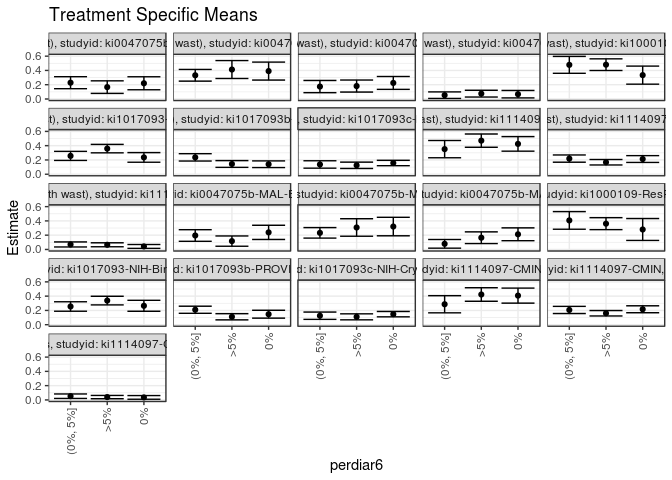

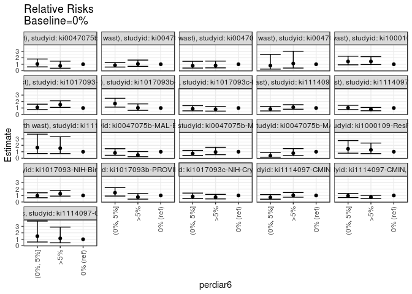

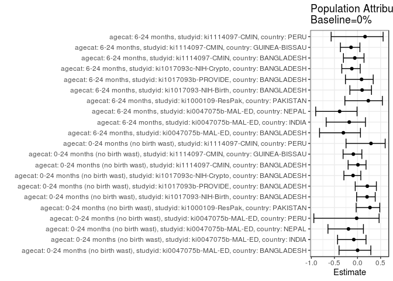

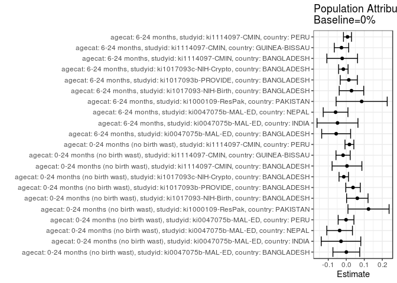

## Results Table

### Parameter: TSM

| agecat | studyid | country | intervention_level | baseline_level | estimate | ci_lower | ci_upper |
| --- | --- | --- | --- | --- | --- | --- | --- |
| 0-24 months (no birth wast) | ki0047075b-MAL-ED | BANGLADESH | 0% | NA | 0.2201373 | 0.1291426 | 0.3111321 |
| 0-24 months (no birth wast) | ki0047075b-MAL-ED | BANGLADESH | (0%, 5%] | NA | 0.2285392 | 0.1444903 | 0.3125882 |
| 0-24 months (no birth wast) | ki0047075b-MAL-ED | BANGLADESH | >5% | NA | 0.1664130 | 0.0782459 | 0.2545802 |
| 0-24 months (no birth wast) | ki0047075b-MAL-ED | INDIA | 0% | NA | 0.3909466 | 0.2650758 | 0.5168174 |
| 0-24 months (no birth wast) | ki0047075b-MAL-ED | INDIA | (0%, 5%] | NA | 0.3322099 | 0.2503569 | 0.4140628 |
| 0-24 months (no birth wast) | ki0047075b-MAL-ED | INDIA | >5% | NA | 0.4126440 | 0.2871767 | 0.5381113 |
| 0-24 months (no birth wast) | ki0047075b-MAL-ED | NEPAL | 0% | NA | 0.2251214 | 0.1349844 | 0.3152585 |
| 0-24 months (no birth wast) | ki0047075b-MAL-ED | NEPAL | (0%, 5%] | NA | 0.1740825 | 0.0886434 | 0.2595216 |
| 0-24 months (no birth wast) | ki0047075b-MAL-ED | NEPAL | >5% | NA | 0.1812396 | 0.0969781 | 0.2655010 |
| 0-24 months (no birth wast) | ki0047075b-MAL-ED | PERU | 0% | NA | 0.0674157 | 0.0152365 | 0.1195950 |
| 0-24 months (no birth wast) | ki0047075b-MAL-ED | PERU | (0%, 5%] | NA | 0.0537634 | 0.0078468 | 0.0996801 |
| 0-24 months (no birth wast) | ki0047075b-MAL-ED | PERU | >5% | NA | 0.0750000 | 0.0277960 | 0.1222040 |
| 0-24 months (no birth wast) | ki1000109-ResPak | PAKISTAN | 0% | NA | 0.3342590 | 0.2077961 | 0.4607220 |
| 0-24 months (no birth wast) | ki1000109-ResPak | PAKISTAN | (0%, 5%] | NA | 0.4782313 | 0.3598424 | 0.5966202 |
| 0-24 months (no birth wast) | ki1000109-ResPak | PAKISTAN | >5% | NA | 0.4807596 | 0.3990940 | 0.5624252 |
| 0-24 months (no birth wast) | ki1017093-NIH-Birth | BANGLADESH | 0% | NA | 0.2357101 | 0.1683414 | 0.3030788 |
| 0-24 months (no birth wast) | ki1017093-NIH-Birth | BANGLADESH | (0%, 5%] | NA | 0.2567606 | 0.1930079 | 0.3205133 |
| 0-24 months (no birth wast) | ki1017093-NIH-Birth | BANGLADESH | >5% | NA | 0.3587466 | 0.2998329 | 0.4176603 |
| 0-24 months (no birth wast) | ki1017093b-PROVIDE | BANGLADESH | 0% | NA | 0.1399406 | 0.0932705 | 0.1866107 |
| 0-24 months (no birth wast) | ki1017093b-PROVIDE | BANGLADESH | (0%, 5%] | NA | 0.2362679 | 0.1849175 | 0.2876183 |
| 0-24 months (no birth wast) | ki1017093b-PROVIDE | BANGLADESH | >5% | NA | 0.1434563 | 0.0961733 | 0.1907393 |
| 0-24 months (no birth wast) | ki1017093c-NIH-Crypto | BANGLADESH | 0% | NA | 0.1570602 | 0.1194530 | 0.1946674 |
| 0-24 months (no birth wast) | ki1017093c-NIH-Crypto | BANGLADESH | (0%, 5%] | NA | 0.1370207 | 0.0852153 | 0.1888260 |
| 0-24 months (no birth wast) | ki1017093c-NIH-Crypto | BANGLADESH | >5% | NA | 0.1251152 | 0.0808384 | 0.1693919 |
| 0-24 months (no birth wast) | ki1114097-CMIN | BANGLADESH | 0% | NA | 0.4250531 | 0.3231443 | 0.5269619 |
| 0-24 months (no birth wast) | ki1114097-CMIN | BANGLADESH | (0%, 5%] | NA | 0.3515645 | 0.2308939 | 0.4722350 |
| 0-24 months (no birth wast) | ki1114097-CMIN | BANGLADESH | >5% | NA | 0.4705873 | 0.3777270 | 0.5634477 |
| 0-24 months (no birth wast) | ki1114097-CMIN | GUINEA-BISSAU | 0% | NA | 0.2128198 | 0.1650540 | 0.2605856 |
| 0-24 months (no birth wast) | ki1114097-CMIN | GUINEA-BISSAU | (0%, 5%] | NA | 0.2191896 | 0.1684679 | 0.2699113 |
| 0-24 months (no birth wast) | ki1114097-CMIN | GUINEA-BISSAU | >5% | NA | 0.1679068 | 0.1296835 | 0.2061300 |
| 0-24 months (no birth wast) | ki1114097-CMIN | PERU | 0% | NA | 0.0424528 | 0.0152937 | 0.0696120 |
| 0-24 months (no birth wast) | ki1114097-CMIN | PERU | (0%, 5%] | NA | 0.0700000 | 0.0346144 | 0.1053856 |
| 0-24 months (no birth wast) | ki1114097-CMIN | PERU | >5% | NA | 0.0655738 | 0.0377742 | 0.0933734 |
| 6-24 months | ki0047075b-MAL-ED | BANGLADESH | 0% | NA | 0.2394366 | 0.1399674 | 0.3389058 |
| 6-24 months | ki0047075b-MAL-ED | BANGLADESH | (0%, 5%] | NA | 0.1956522 | 0.1144206 | 0.2768838 |
| 6-24 months | ki0047075b-MAL-ED | BANGLADESH | >5% | NA | 0.1168831 | 0.0449723 | 0.1887940 |
| 6-24 months | ki0047075b-MAL-ED | INDIA | 0% | NA | 0.3210546 | 0.1913931 | 0.4507160 |
| 6-24 months | ki0047075b-MAL-ED | INDIA | (0%, 5%] | NA | 0.2326077 | 0.1589908 | 0.3062245 |
| 6-24 months | ki0047075b-MAL-ED | INDIA | >5% | NA | 0.3077396 | 0.1850621 | 0.4304171 |
| 6-24 months | ki0047075b-MAL-ED | NEPAL | 0% | NA | 0.2125000 | 0.1226674 | 0.3023326 |
| 6-24 months | ki0047075b-MAL-ED | NEPAL | (0%, 5%] | NA | 0.0789474 | 0.0181929 | 0.1397019 |
| 6-24 months | ki0047075b-MAL-ED | NEPAL | >5% | NA | 0.1645570 | 0.0826205 | 0.2464934 |
| 6-24 months | ki1000109-ResPak | PAKISTAN | 0% | NA | 0.2797033 | 0.1261517 | 0.4332550 |
| 6-24 months | ki1000109-ResPak | PAKISTAN | (0%, 5%] | NA | 0.4070723 | 0.2836661 | 0.5304784 |
| 6-24 months | ki1000109-ResPak | PAKISTAN | >5% | NA | 0.3614589 | 0.2777015 | 0.4452163 |
| 6-24 months | ki1017093-NIH-Birth | BANGLADESH | 0% | NA | 0.2648749 | 0.1880625 | 0.3416873 |
| 6-24 months | ki1017093-NIH-Birth | BANGLADESH | (0%, 5%] | NA | 0.2550283 | 0.1887761 | 0.3212805 |
| 6-24 months | ki1017093-NIH-Birth | BANGLADESH | >5% | NA | 0.3378890 | 0.2774716 | 0.3983064 |
| 6-24 months | ki1017093b-PROVIDE | BANGLADESH | 0% | NA | 0.1468600 | 0.0918311 | 0.2018889 |
| 6-24 months | ki1017093b-PROVIDE | BANGLADESH | (0%, 5%] | NA | 0.2093738 | 0.1596475 | 0.2591001 |
| 6-24 months | ki1017093b-PROVIDE | BANGLADESH | >5% | NA | 0.1110246 | 0.0676556 | 0.1543936 |
| 6-24 months | ki1017093c-NIH-Crypto | BANGLADESH | 0% | NA | 0.1477259 | 0.1100704 | 0.1853814 |
| 6-24 months | ki1017093c-NIH-Crypto | BANGLADESH | (0%, 5%] | NA | 0.1258780 | 0.0747918 | 0.1769642 |
| 6-24 months | ki1017093c-NIH-Crypto | BANGLADESH | >5% | NA | 0.1102203 | 0.0681380 | 0.1523025 |
| 6-24 months | ki1114097-CMIN | BANGLADESH | 0% | NA | 0.4074576 | 0.3020364 | 0.5128789 |
| 6-24 months | ki1114097-CMIN | BANGLADESH | (0%, 5%] | NA | 0.2864742 | 0.1663251 | 0.4066234 |
| 6-24 months | ki1114097-CMIN | BANGLADESH | >5% | NA | 0.4229445 | 0.3281856 | 0.5177033 |
| 6-24 months | ki1114097-CMIN | GUINEA-BISSAU | 0% | NA | 0.2162091 | 0.1676735 | 0.2647447 |
| 6-24 months | ki1114097-CMIN | GUINEA-BISSAU | (0%, 5%] | NA | 0.2066202 | 0.1563124 | 0.2569280 |
| 6-24 months | ki1114097-CMIN | GUINEA-BISSAU | >5% | NA | 0.1604196 | 0.1225150 | 0.1983242 |
| 6-24 months | ki1114097-CMIN | PERU | 0% | NA | 0.0351759 | 0.0095609 | 0.0607909 |
| 6-24 months | ki1114097-CMIN | PERU | (0%, 5%] | NA | 0.0520833 | 0.0206306 | 0.0835361 |
| 6-24 months | ki1114097-CMIN | PERU | >5% | NA | 0.0400000 | 0.0168221 | 0.0631779 |

### Parameter: E(Y)

| agecat | studyid | country | intervention_level | baseline_level | estimate | ci_lower | ci_upper |
| --- | --- | --- | --- | --- | --- | --- | --- |
| 0-24 months (no birth wast) | ki0047075b-MAL-ED | BANGLADESH | NA | NA | 0.2205323 | 0.1703290 | 0.2707357 |
| 0-24 months (no birth wast) | ki0047075b-MAL-ED | INDIA | NA | NA | 0.3617886 | 0.3016193 | 0.4219579 |
| 0-24 months (no birth wast) | ki0047075b-MAL-ED | NEPAL | NA | NA | 0.1882845 | 0.1386174 | 0.2379516 |
| 0-24 months (no birth wast) | ki0047075b-MAL-ED | PERU | NA | NA | 0.0662252 | 0.0381322 | 0.0943181 |
| 0-24 months (no birth wast) | ki1000109-ResPak | PAKISTAN | NA | NA | 0.4578755 | 0.3986666 | 0.5170843 |
| 0-24 months (no birth wast) | ki1017093-NIH-Birth | BANGLADESH | NA | NA | 0.2971619 | 0.2605332 | 0.3337907 |
| 0-24 months (no birth wast) | ki1017093b-PROVIDE | BANGLADESH | NA | NA | 0.1775837 | 0.1489858 | 0.2061816 |
| 0-24 months (no birth wast) | ki1017093c-NIH-Crypto | BANGLADESH | NA | NA | 0.1432361 | 0.1182149 | 0.1682572 |
| 0-24 months (no birth wast) | ki1114097-CMIN | BANGLADESH | NA | NA | 0.4291045 | 0.3697365 | 0.4884725 |
| 0-24 months (no birth wast) | ki1114097-CMIN | GUINEA-BISSAU | NA | NA | 0.1951754 | 0.1694388 | 0.2209121 |
| 0-24 months (no birth wast) | ki1114097-CMIN | PERU | NA | NA | 0.0599721 | 0.0425806 | 0.0773636 |
| 6-24 months | ki0047075b-MAL-ED | BANGLADESH | NA | NA | 0.1833333 | 0.1342773 | 0.2323893 |
| 6-24 months | ki0047075b-MAL-ED | INDIA | NA | NA | 0.2723404 | 0.2153029 | 0.3293779 |
| 6-24 months | ki0047075b-MAL-ED | NEPAL | NA | NA | 0.1531915 | 0.1070438 | 0.1993392 |
| 6-24 months | ki1000109-ResPak | PAKISTAN | NA | NA | 0.3652174 | 0.3028556 | 0.4275792 |
| 6-24 months | ki1017093-NIH-Birth | BANGLADESH | NA | NA | 0.2939002 | 0.2554778 | 0.3323226 |
| 6-24 months | ki1017093b-PROVIDE | BANGLADESH | NA | NA | 0.1609756 | 0.1319065 | 0.1900447 |
| 6-24 months | ki1017093c-NIH-Crypto | BANGLADESH | NA | NA | 0.1315068 | 0.1069744 | 0.1560393 |
| 6-24 months | ki1114097-CMIN | BANGLADESH | NA | NA | 0.3849206 | 0.3247254 | 0.4451159 |
| 6-24 months | ki1114097-CMIN | GUINEA-BISSAU | NA | NA | 0.1896745 | 0.1639180 | 0.2154311 |
| 6-24 months | ki1114097-CMIN | PERU | NA | NA | 0.0420420 | 0.0267891 | 0.0572949 |

### Parameter: RR

| agecat | studyid | country | intervention_level | baseline_level | estimate | ci_lower | ci_upper |
| --- | --- | --- | --- | --- | --- | --- | --- |
| 0-24 months (no birth wast) | ki0047075b-MAL-ED | BANGLADESH | 0% | 0% | 1.0000000 | 1.0000000 | 1.0000000 |
| 0-24 months (no birth wast) | ki0047075b-MAL-ED | BANGLADESH | (0%, 5%] | 0% | 1.0381666 | 0.5959807 | 1.8084308 |
| 0-24 months (no birth wast) | ki0047075b-MAL-ED | BANGLADESH | >5% | 0% | 0.7559510 | 0.3862603 | 1.4794737 |
| 0-24 months (no birth wast) | ki0047075b-MAL-ED | INDIA | 0% | 0% | 1.0000000 | 1.0000000 | 1.0000000 |
| 0-24 months (no birth wast) | ki0047075b-MAL-ED | INDIA | (0%, 5%] | 0% | 0.8497578 | 0.5665722 | 1.2744859 |
| 0-24 months (no birth wast) | ki0047075b-MAL-ED | INDIA | >5% | 0% | 1.0554997 | 0.6756205 | 1.6489725 |
| 0-24 months (no birth wast) | ki0047075b-MAL-ED | NEPAL | 0% | 0% | 1.0000000 | 1.0000000 | 1.0000000 |
| 0-24 months (no birth wast) | ki0047075b-MAL-ED | NEPAL | (0%, 5%] | 0% | 0.7732825 | 0.4099914 | 1.4584836 |
| 0-24 months (no birth wast) | ki0047075b-MAL-ED | NEPAL | >5% | 0% | 0.8050746 | 0.4352711 | 1.4890608 |
| 0-24 months (no birth wast) | ki0047075b-MAL-ED | PERU | 0% | 0% | 1.0000000 | 1.0000000 | 1.0000000 |
| 0-24 months (no birth wast) | ki0047075b-MAL-ED | PERU | (0%, 5%] | 0% | 0.7974910 | 0.2518616 | 2.5251640 |
| 0-24 months (no birth wast) | ki0047075b-MAL-ED | PERU | >5% | 0% | 1.1125000 | 0.4102520 | 3.0168196 |
| 0-24 months (no birth wast) | ki1000109-ResPak | PAKISTAN | 0% | 0% | 1.0000000 | 1.0000000 | 1.0000000 |
| 0-24 months (no birth wast) | ki1000109-ResPak | PAKISTAN | (0%, 5%] | 0% | 1.4307207 | 0.9100933 | 2.2491779 |
| 0-24 months (no birth wast) | ki1000109-ResPak | PAKISTAN | >5% | 0% | 1.4382845 | 0.9492617 | 2.1792330 |
| 0-24 months (no birth wast) | ki1017093-NIH-Birth | BANGLADESH | 0% | 0% | 1.0000000 | 1.0000000 | 1.0000000 |
| 0-24 months (no birth wast) | ki1017093-NIH-Birth | BANGLADESH | (0%, 5%] | 0% | 1.0893065 | 0.7464337 | 1.5896772 |
| 0-24 months (no birth wast) | ki1017093-NIH-Birth | BANGLADESH | >5% | 0% | 1.5219822 | 1.0951384 | 2.1151938 |
| 0-24 months (no birth wast) | ki1017093b-PROVIDE | BANGLADESH | 0% | 0% | 1.0000000 | 1.0000000 | 1.0000000 |
| 0-24 months (no birth wast) | ki1017093b-PROVIDE | BANGLADESH | (0%, 5%] | 0% | 1.6883444 | 1.1362774 | 2.5086365 |
| 0-24 months (no birth wast) | ki1017093b-PROVIDE | BANGLADESH | >5% | 0% | 1.0251229 | 0.6421627 | 1.6364653 |
| 0-24 months (no birth wast) | ki1017093c-NIH-Crypto | BANGLADESH | 0% | 0% | 1.0000000 | 1.0000000 | 1.0000000 |
| 0-24 months (no birth wast) | ki1017093c-NIH-Crypto | BANGLADESH | (0%, 5%] | 0% | 0.8724085 | 0.5576468 | 1.3648364 |
| 0-24 months (no birth wast) | ki1017093c-NIH-Crypto | BANGLADESH | >5% | 0% | 0.7966064 | 0.5195586 | 1.2213864 |
| 0-24 months (no birth wast) | ki1114097-CMIN | BANGLADESH | 0% | 0% | 1.0000000 | 1.0000000 | 1.0000000 |
| 0-24 months (no birth wast) | ki1114097-CMIN | BANGLADESH | (0%, 5%] | 0% | 0.8271072 | 0.5442975 | 1.2568609 |
| 0-24 months (no birth wast) | ki1114097-CMIN | BANGLADESH | >5% | 0% | 1.1071259 | 0.8124353 | 1.5087082 |
| 0-24 months (no birth wast) | ki1114097-CMIN | GUINEA-BISSAU | 0% | 0% | 1.0000000 | 1.0000000 | 1.0000000 |
| 0-24 months (no birth wast) | ki1114097-CMIN | GUINEA-BISSAU | (0%, 5%] | 0% | 1.0299306 | 0.7466309 | 1.4207248 |
| 0-24 months (no birth wast) | ki1114097-CMIN | GUINEA-BISSAU | >5% | 0% | 0.7889621 | 0.5734855 | 1.0854001 |
| 0-24 months (no birth wast) | ki1114097-CMIN | PERU | 0% | 0% | 1.0000000 | 1.0000000 | 1.0000000 |
| 0-24 months (no birth wast) | ki1114097-CMIN | PERU | (0%, 5%] | 0% | 1.6488888 | 0.7295974 | 3.7264856 |
| 0-24 months (no birth wast) | ki1114097-CMIN | PERU | >5% | 0% | 1.5446265 | 0.7169949 | 3.3275981 |
| 6-24 months | ki0047075b-MAL-ED | BANGLADESH | 0% | 0% | 1.0000000 | 1.0000000 | 1.0000000 |
| 6-24 months | ki0047075b-MAL-ED | BANGLADESH | (0%, 5%] | 0% | 0.8171355 | 0.4541703 | 1.4701766 |
| 6-24 months | ki0047075b-MAL-ED | BANGLADESH | >5% | 0% | 0.4881589 | 0.2323583 | 1.0255675 |
| 6-24 months | ki0047075b-MAL-ED | INDIA | 0% | 0% | 1.0000000 | 1.0000000 | 1.0000000 |
| 6-24 months | ki0047075b-MAL-ED | INDIA | (0%, 5%] | 0% | 0.7245113 | 0.4350423 | 1.2065877 |
| 6-24 months | ki0047075b-MAL-ED | INDIA | >5% | 0% | 0.9585273 | 0.5444114 | 1.6876476 |
| 6-24 months | ki0047075b-MAL-ED | NEPAL | 0% | 0% | 1.0000000 | 1.0000000 | 1.0000000 |
| 6-24 months | ki0047075b-MAL-ED | NEPAL | (0%, 5%] | 0% | 0.3715170 | 0.1544035 | 0.8939232 |
| 6-24 months | ki0047075b-MAL-ED | NEPAL | >5% | 0% | 0.7743857 | 0.4029837 | 1.4880830 |
| 6-24 months | ki1000109-ResPak | PAKISTAN | 0% | 0% | 1.0000000 | 1.0000000 | 1.0000000 |
| 6-24 months | ki1000109-ResPak | PAKISTAN | (0%, 5%] | 0% | 1.4553716 | 0.7772532 | 2.7251177 |
| 6-24 months | ki1000109-ResPak | PAKISTAN | >5% | 0% | 1.2922939 | 0.7120563 | 2.3453531 |
| 6-24 months | ki1017093-NIH-Birth | BANGLADESH | 0% | 0% | 1.0000000 | 1.0000000 | 1.0000000 |
| 6-24 months | ki1017093-NIH-Birth | BANGLADESH | (0%, 5%] | 0% | 0.9628255 | 0.6526112 | 1.4204980 |
| 6-24 months | ki1017093-NIH-Birth | BANGLADESH | >5% | 0% | 1.2756548 | 0.9079325 | 1.7923087 |
| 6-24 months | ki1017093b-PROVIDE | BANGLADESH | 0% | 0% | 1.0000000 | 1.0000000 | 1.0000000 |
| 6-24 months | ki1017093b-PROVIDE | BANGLADESH | (0%, 5%] | 0% | 1.4256697 | 0.9174437 | 2.2154319 |
| 6-24 months | ki1017093b-PROVIDE | BANGLADESH | >5% | 0% | 0.7559893 | 0.4407752 | 1.2966245 |
| 6-24 months | ki1017093c-NIH-Crypto | BANGLADESH | 0% | 0% | 1.0000000 | 1.0000000 | 1.0000000 |
| 6-24 months | ki1017093c-NIH-Crypto | BANGLADESH | (0%, 5%] | 0% | 0.8521053 | 0.5277985 | 1.3756831 |
| 6-24 months | ki1017093c-NIH-Crypto | BANGLADESH | >5% | 0% | 0.7461134 | 0.4716004 | 1.1804172 |
| 6-24 months | ki1114097-CMIN | BANGLADESH | 0% | 0% | 1.0000000 | 1.0000000 | 1.0000000 |
| 6-24 months | ki1114097-CMIN | BANGLADESH | (0%, 5%] | 0% | 0.7030773 | 0.4298888 | 1.1498733 |
| 6-24 months | ki1114097-CMIN | BANGLADESH | >5% | 0% | 1.0380085 | 0.7369344 | 1.4620861 |
| 6-24 months | ki1114097-CMIN | GUINEA-BISSAU | 0% | 0% | 1.0000000 | 1.0000000 | 1.0000000 |
| 6-24 months | ki1114097-CMIN | GUINEA-BISSAU | (0%, 5%] | 0% | 0.9556498 | 0.6865002 | 1.3303221 |
| 6-24 months | ki1114097-CMIN | GUINEA-BISSAU | >5% | 0% | 0.7419651 | 0.5359334 | 1.0272029 |
| 6-24 months | ki1114097-CMIN | PERU | 0% | 0% | 1.0000000 | 1.0000000 | 1.0000000 |
| 6-24 months | ki1114097-CMIN | PERU | (0%, 5%] | 0% | 1.4806548 | 0.5749123 | 3.8133446 |
| 6-24 months | ki1114097-CMIN | PERU | >5% | 0% | 1.1371429 | 0.4483913 | 2.8838514 |

### Parameter: PAR

| agecat | studyid | country | intervention_level | baseline_level | estimate | ci_lower | ci_upper |
| --- | --- | --- | --- | --- | --- | --- | --- |
| 0-24 months (no birth wast) | ki0047075b-MAL-ED | BANGLADESH | 0% | NA | 0.0003950 | -0.0740512 | 0.0748412 |
| 0-24 months (no birth wast) | ki0047075b-MAL-ED | INDIA | 0% | NA | -0.0291580 | -0.1389899 | 0.0806740 |
| 0-24 months (no birth wast) | ki0047075b-MAL-ED | NEPAL | 0% | NA | -0.0368369 | -0.1080693 | 0.0343954 |
| 0-24 months (no birth wast) | ki0047075b-MAL-ED | PERU | 0% | NA | -0.0011906 | -0.0448613 | 0.0424802 |
| 0-24 months (no birth wast) | ki1000109-ResPak | PAKISTAN | 0% | NA | 0.1236164 | 0.0094510 | 0.2377818 |
| 0-24 months (no birth wast) | ki1017093-NIH-Birth | BANGLADESH | 0% | NA | 0.0614518 | 0.0019871 | 0.1209166 |
| 0-24 months (no birth wast) | ki1017093b-PROVIDE | BANGLADESH | 0% | NA | 0.0376431 | -0.0027231 | 0.0780093 |
| 0-24 months (no birth wast) | ki1017093c-NIH-Crypto | BANGLADESH | 0% | NA | -0.0138241 | -0.0400142 | 0.0123659 |
| 0-24 months (no birth wast) | ki1114097-CMIN | BANGLADESH | 0% | NA | 0.0040514 | -0.0786228 | 0.0867255 |
| 0-24 months (no birth wast) | ki1114097-CMIN | GUINEA-BISSAU | 0% | NA | -0.0176444 | -0.0570785 | 0.0217897 |
| 0-24 months (no birth wast) | ki1114097-CMIN | PERU | 0% | NA | 0.0175193 | -0.0070549 | 0.0420935 |
| 6-24 months | ki0047075b-MAL-ED | BANGLADESH | 0% | NA | -0.0561033 | -0.1363940 | 0.0241874 |
| 6-24 months | ki0047075b-MAL-ED | INDIA | 0% | NA | -0.0487141 | -0.1622831 | 0.0648549 |
| 6-24 months | ki0047075b-MAL-ED | NEPAL | 0% | NA | -0.0593085 | -0.1279023 | 0.0092853 |
| 6-24 months | ki1000109-ResPak | PAKISTAN | 0% | NA | 0.0855141 | -0.0563686 | 0.2273967 |
| 6-24 months | ki1017093-NIH-Birth | BANGLADESH | 0% | NA | 0.0290253 | -0.0390361 | 0.0970866 |
| 6-24 months | ki1017093b-PROVIDE | BANGLADESH | 0% | NA | 0.0141157 | -0.0334658 | 0.0616971 |
| 6-24 months | ki1017093c-NIH-Crypto | BANGLADESH | 0% | NA | -0.0162190 | -0.0424396 | 0.0100015 |
| 6-24 months | ki1114097-CMIN | BANGLADESH | 0% | NA | -0.0225370 | -0.1076814 | 0.0626074 |
| 6-24 months | ki1114097-CMIN | GUINEA-BISSAU | 0% | NA | -0.0265346 | -0.0663835 | 0.0133144 |
| 6-24 months | ki1114097-CMIN | PERU | 0% | NA | 0.0068662 | -0.0154201 | 0.0291524 |

### Parameter: PAF

| agecat | studyid | country | intervention_level | baseline_level | estimate | ci_lower | ci_upper |
| --- | --- | --- | --- | --- | --- | --- | --- |
| 0-24 months (no birth wast) | ki0047075b-MAL-ED | BANGLADESH | 0% | NA | 0.0017910 | -0.3998990 | 0.2882193 |
| 0-24 months (no birth wast) | ki0047075b-MAL-ED | INDIA | 0% | NA | -0.0805939 | -0.4312854 | 0.1841717 |
| 0-24 months (no birth wast) | ki0047075b-MAL-ED | NEPAL | 0% | NA | -0.1956450 | -0.6396541 | 0.1281290 |
| 0-24 months (no birth wast) | ki0047075b-MAL-ED | PERU | 0% | NA | -0.0179775 | -0.9455866 | 0.4673698 |
| 0-24 months (no birth wast) | ki1000109-ResPak | PAKISTAN | 0% | NA | 0.2699782 | -0.0286821 | 0.4819276 |
| 0-24 months (no birth wast) | ki1017093-NIH-Birth | BANGLADESH | 0% | NA | 0.2067958 | -0.0203533 | 0.3833773 |
| 0-24 months (no birth wast) | ki1017093b-PROVIDE | BANGLADESH | 0% | NA | 0.2119739 | -0.0496168 | 0.4083697 |
| 0-24 months (no birth wast) | ki1017093c-NIH-Crypto | BANGLADESH | 0% | NA | -0.0965129 | -0.2948495 | 0.0714439 |
| 0-24 months (no birth wast) | ki1114097-CMIN | BANGLADESH | 0% | NA | 0.0094414 | -0.2032482 | 0.1845354 |
| 0-24 months (no birth wast) | ki1114097-CMIN | GUINEA-BISSAU | 0% | NA | -0.0904025 | -0.3123472 | 0.0940068 |
| 0-24 months (no birth wast) | ki1114097-CMIN | PERU | 0% | NA | 0.2921237 | -0.2485810 | 0.5986733 |
| 6-24 months | ki0047075b-MAL-ED | BANGLADESH | 0% | NA | -0.3060179 | -0.8219023 | 0.0637902 |
| 6-24 months | ki0047075b-MAL-ED | INDIA | 0% | NA | -0.1788722 | -0.6788379 | 0.1722013 |
| 6-24 months | ki0047075b-MAL-ED | NEPAL | 0% | NA | -0.3871528 | -0.9051231 | -0.0100097 |
| 6-24 months | ki1000109-ResPak | PAKISTAN | 0% | NA | 0.2341457 | -0.2736410 | 0.5394834 |
| 6-24 months | ki1017093-NIH-Birth | BANGLADESH | 0% | NA | 0.0987589 | -0.1650948 | 0.3028589 |
| 6-24 months | ki1017093b-PROVIDE | BANGLADESH | 0% | NA | 0.0876881 | -0.2613423 | 0.3401371 |
| 6-24 months | ki1017093c-NIH-Crypto | BANGLADESH | 0% | NA | -0.1233323 | -0.3403443 | 0.0585438 |
| 6-24 months | ki1114097-CMIN | BANGLADESH | 0% | NA | -0.0585498 | -0.3045274 | 0.1410471 |
| 6-24 months | ki1114097-CMIN | GUINEA-BISSAU | 0% | NA | -0.1398954 | -0.3704650 | 0.0518828 |
| 6-24 months | ki1114097-CMIN | PERU | 0% | NA | 0.1633166 | -0.5707920 | 0.5543400 |